# HW1: Data Visualization

# Homework 1

### Instructions

1. All assignments are individual!
2. This assignment should be uploaded as one html file (after knit) before the next Tutorial.
3. Questions about the assignment should be asked using the Assignments forums.
4. Write your name and id at the top of the file

```r
#knitr::opts_chunk$set(echo = TRUE)
knitr::opts_chunk$set(warning = FALSE, message = FALSE)
library(tidyverse)
```

### MPG dataset

```r
data(mpg)
```

```r
str(mpg)
```

```
## tibble [234 × 11] (S3: tbl_df/tbl/data.frame)
##  $ manufacturer: chr [1:234] "audi" "audi" "audi" "audi" ...
##  $ model       : chr [1:234] "a4" "a4" "a4" "a4" ...
##  $ displ       : num [1:234] 1.8 1.8 2 2 2.8 2.8 3.1 1.8 1.8 2 ...
##  $ year        : int [1:234] 1999 1999 2008 2008 1999 1999 2008 1999 1999 2008 ...
##  $ cyl         : int [1:234] 4 4 4 4 6 6 6 4 4 4 ...
##  $ trans       : chr [1:234] "auto(l5)" "manual(m5)" "manual(m6)" "auto(av)" ...
##  $ drv         : chr [1:234] "f" "f" "f" "f" ...
##  $ cty         : int [1:234] 18 21 20 21 16 18 18 18 16 20 ...
##  $ hwy         : int [1:234] 29 29 31 30 26 26 27 26 25 28 ...
##  $ fl          : chr [1:234] "p" "p" "p" "p" ...
##  $ class       : chr [1:234] "compact" "compact" "compact" "compact" ...
```

## Problem 1: Histograms

Using the `mpg` dataset from `ggplot2`:

- Create histograms for the variable `hwy`, grouped by vehicle `class`.
- Briefly describe differences between the classes.

Two relatively clear trends can be observed: smaller cars such as midsize, compact, and subcompact consume less fuel compared to larger vehicles like minivan, SUV, and pickup. The 2seater category is surprising, showing high fuel consumption despite its small size—likely due to other factors.

```r
range(mpg$hwy)
```

```
## [1] 12 44
```

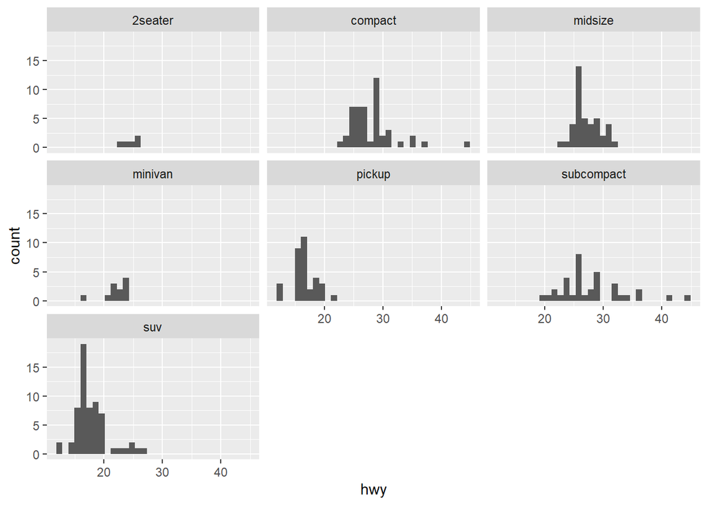

```r
library(ggplot2)
ggplot(mpg, aes(x = hwy))+
geom_histogram(bins = 32)+
facet_wrap(~ class)
```

## Problem 2: Boxplots

Using the `mpg` dataset:

- Create boxplots of `cty` (city mileage) grouped by `drv` (type of drive train).
- Identify and briefly discuss any noticeable outliers.

In the front-wheel drive (f) category, the median is the highest, indicating the most fuel-efficient performance in city driving. However, this category also includes several anomalies — some highly fuel-efficient vehicles (possibly hybrids or electric cars that may have been grouped here), and one notably inefficient outlier.

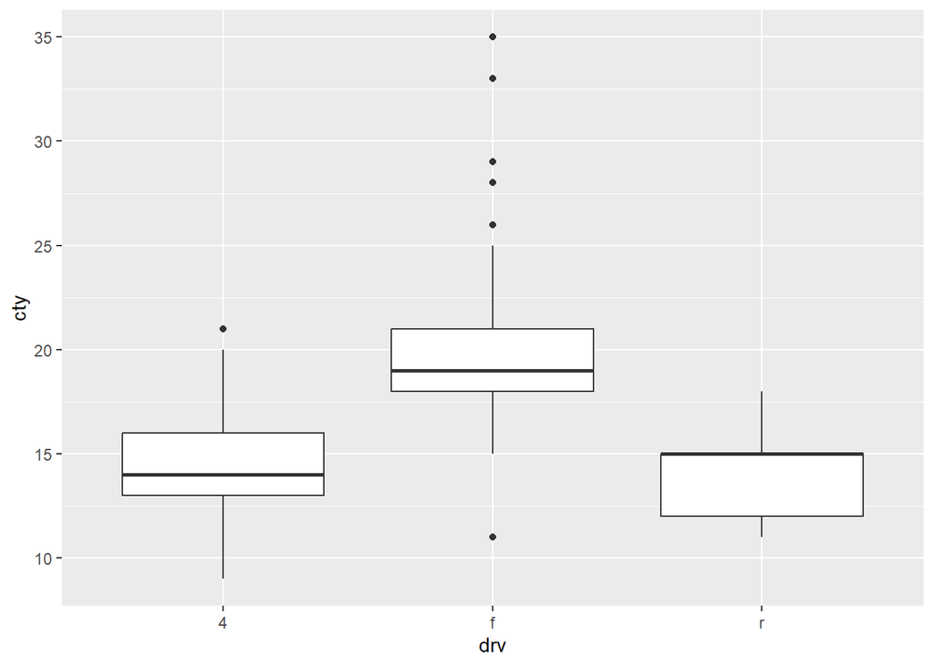

```r
ggplot(mpg, aes(x = drv, y = cty)) +
  geom_boxplot()
```

## Problem 3: Scatterplots

Using the `mpg` dataset:

- Create a scatterplot of `displ` (engine displacement) vs. `hwy` (highway mileage).
- Briefly describe the relationship.
- Use the `class` variable to color the points and briefly discuss insights gained.

We can observe the same trend seen in the histogram from Exercise 1, only more clearly here. As the engine displacement increases, the hwy value decreases — meaning the car consumes more fuel. This helps explain why the 2seater category had high fuel consumption in Exercise 1, despite not being a large vehicle like the others. This scatterplot shows that the reason is likely due to its large engine size.

```r
range(mpg$displ)
```

```
## [1] 1.6 7.0
```

```r
range(mpg$hwy)
```

```
## [1] 12 44
```

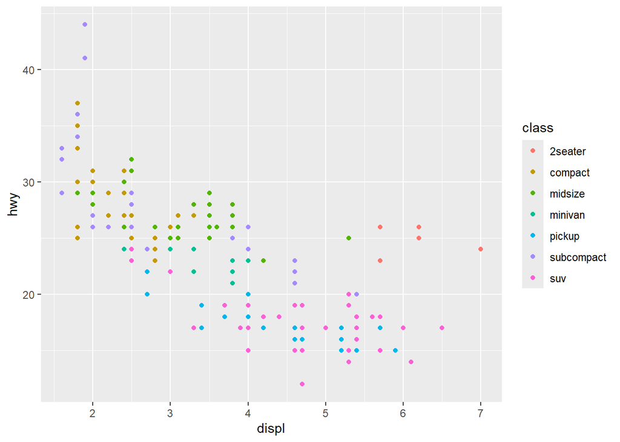

```r
ggplot(data = mpg, aes(x = displ, y =hwy, color = class)) +
  geom_point()
```

```r
  coord_cartesian(xlim = c(1, 7), ylim = c(10, 45))
```

[output not shown]

## Problem 4: 5 parameters in one graph

- Pick 3 numerical variables and 2 categorical variable and make a visualization of them and provide an interpretation with your answer.

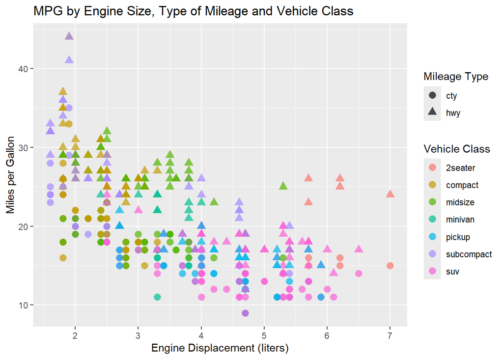

```r
library(tidyverse)

mpg_long <- mpg %>%
  pivot_longer(cols = c(cty, hwy), names_to = "mileage_type", values_to = "mpg_value")

ggplot(mpg_long, aes(x = displ, y = mpg_value, color = class, shape = mileage_type)) +
  geom_point(alpha = 0.7, size = 3) +
  labs(
    title = "MPG by Engine Size, Type of Mileage and Vehicle Class",
    x = "Engine Displacement (liters)",
    y = "Miles per Gallon",
    color = "Vehicle Class",
    shape = "Mileage Type"
  )
```

## Problem 5: Reflection and Interpretation

Reflect briefly (2-3 sentences each) on the following:

- Why is choosing the right visualization type crucial when exploring data?

I tried to compare city and highway fuel efficiency based on engine size and vehicle class. Putting both into one graph, as required, took some thought to make sure the results were clear. Choosing the right type of graph was important so it wouldn’t be confusing and would show the main patterns. By using pivot_longer(), I managed to include three numeric values (engine size, city MPG, and highway MPG—combined into one), and two categories: the type of mileage (city or highway) and the vehicle class.

- In what ways can misleading visualizations negatively impact decision-making or understanding?

Misleading visualizations can hide or distort the real story. For instance, if I had tried to include both city and highway data in a single plot without structuring it carefully, the result could have been cluttered and hard to interpret. This might mislead someone who is mainly interested in one specific aspect, such as city driving performance.

- Give an example of a situation where visualizing data helped you understand something better or changed your perspective.

When I visualized the relationship between engine size and fuel efficiency across different vehicle types, I was surprised to see that two-seater cars, which I expected to be fuel-efficient due to their small size, actually had poor city mileage.  
This helped me realize that the “two-seater” category might be broader than I initially thought, possibly including powerful sports cars or other high-performance vehicles with large engines — which could explain their lower fuel efficiency.

## Problem 6: write Rcode for the following graphs

### 1. write a code to plot the following plot.

for this question use data(mpg, package=“ggplot2”)

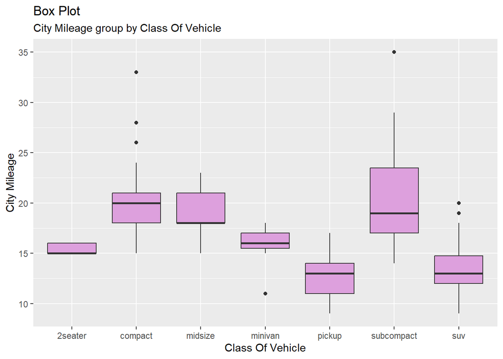

[figure not shown]

```r
ggplot(mpg, aes(x = class, y = cty)) +
  labs(x = "Class Of Vehicle", y = "City Mileage")+
  labs( title = "Box Plot",
        subtitle ="City Mileage group by Class Of Vehicle" )+
  geom_boxplot(fill = "plum")
```

### 2. write a code to plot the following plot

for this question use data(mpg, package=“ggplot2”)

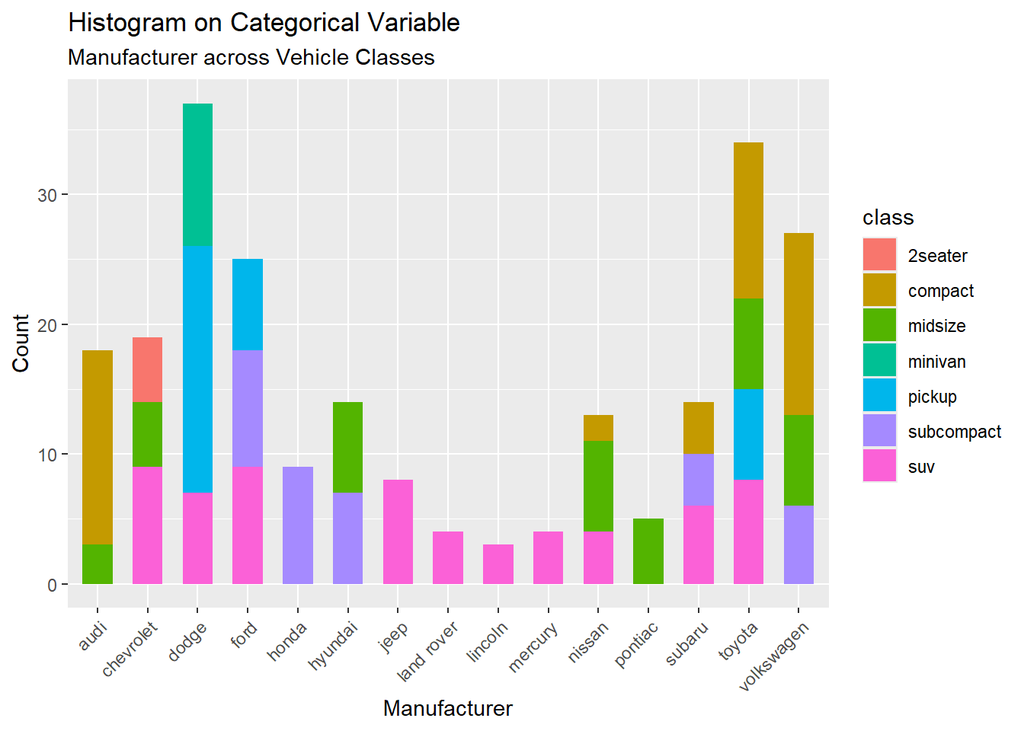

[figure not shown]

```r
ggplot(mpg, aes(x = manufacturer,fill = class))+
labs(title = "Histogram on Categorical Variable",
     subtitle = "Manufacturer across Vehicle Classes",
    x = "Manufacturer",
    y = "Count")+
   theme(axis.text.x = element_text(angle = 45, hjust = 1))+
geom_bar(width = 0.6)
```